# A dendrogram-based approach to OTU clustering

Eliza Grames

12/08/17

## Why cluster OTUs?

- Improve inference and interpretation
- Reduce computatonal load

## Common OTU clustering approaches

- *De novo* clustering
  - Average, single, or complete linkage
  - Allows for flexibility to each study
  - Doesn’t remove novel sequences
- Closed reference
  - e.g. GreenGenes
  - Allows for taxonomic identifaction
- Open reference
  - Combines closed reference with de novo

## Issues with OTU clustering

- Arbitrary cutoff of .03 dissimilarity
- Ignores evolutionary distance and true taxonomy
- Pairwise distances are commonly used instead of multiple sequence alignment, which ignores evolutionary change
- Sequencing errors produce spurious OTUs

## OptiClust

- Default clustering algorithm in mothur
- Maximizes the Matthews Correlation Coefficient
- Based on a .03 dissimilarity cutoff

## Proposed OTU clustering approach

- Use dendrogram edge lengths as a proxy for evolutionary distance
  - Nguyen et al. (2016) proposed basal length based on MSA
  - MSA is sensitive to sequencing errors
- Based on pairwise distances instead of MSA to reduce spurious OTUs
- Not computationally intensive
- More realistic to true taxonomic relationships

## Algorithm development

- Development data was a mock microbial community with equal propotions of *Lactobacillus crispatus*, *Prevotella bivia*, and *Gardnerella vaginalis*
- Algorithm should identify three OTUs and those OTUs should only contain sequences aligning to the three known taxa represented

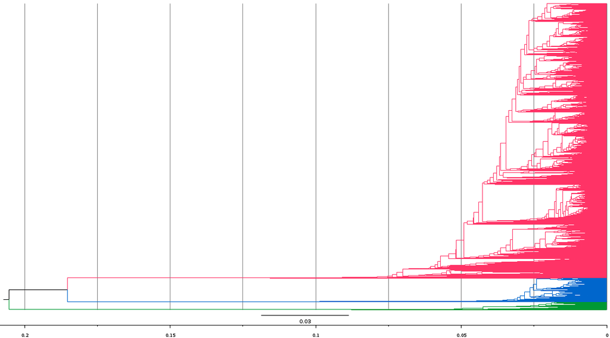

## Data processing in mothur

- Data was screened to remove ambiguous base pairs, limit homopolymers, and remove sequences outside the standard length
- Only unique sequences were used
- Because data is V3V4, I used the entire silva bacteria reference file for alignment

> “I have purposely been obtuse on the forum about this question because I really think it’s a mistake to use regions like the V4-V5 or V3-V4”
- Sequences that differed by 3 base pairs (error rate of 0.69%) were preclustered
- Chimeras were removed with uchime
- Non-bacterial lineages were removed after classification
- A cutoff distance of .00 was used for a lower triangle matrix of pairwise distances

## Clustering in R

- Used the package ape to manipulate the dendrogram
- Collapsed edges less than 10% the total tree length

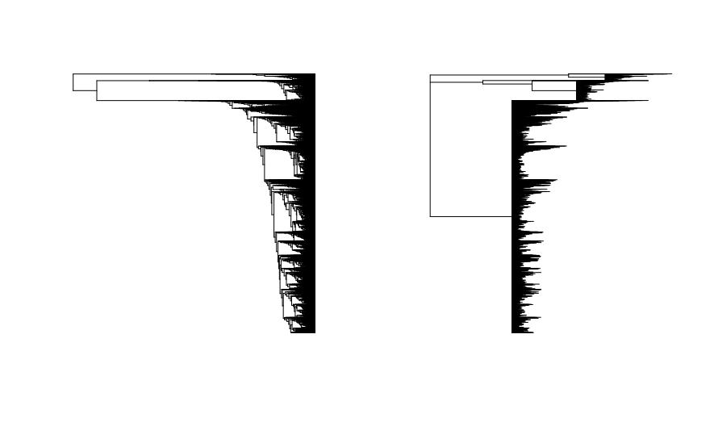

## Clustering in R

- Calculated the average edge distance to a node and from a node

```
##      to.dist.av from.dist.av  dif   ID
## 5590        NaN    0.0773150   NA 5590
## 5591  0.0695651    0.0687254 TRUE 5591
## 5592  0.0687254          NaN   NA 5592
## 5593  0.0447529    0.0418892 TRUE 5593
## 5594  0.0418892    0.0418774 TRUE 5594
## 5595  0.0379300          NaN   NA 5595
## 5596  0.0458248          NaN   NA 5596
## 5597  0.1176270    0.0312733 TRUE 5597
## 5598  0.0312733          NaN   NA 5598
```

## Clustering in R

- Nodes with no children or parents (root and tips) were removed
- Nodes with distance to them greater than distance from them were considered potential nodes
- Potential OTUs cannot be children of other OTUs

```
##   to.dist.av from.dist.av  dif   ID
## 1  0.0695651    0.0687254 TRUE 5591
## 2  0.0447529    0.0418892 TRUE 5593
## 3  0.0418892    0.0418774 TRUE 5594
## 4  0.1176270    0.0312733 TRUE 5597
```

```
## [1] 5594
```

```
##   to.dist.av from.dist.av  dif   ID
## 1  0.0695651    0.0687254 TRUE 5591
## 2  0.0447529    0.0418892 TRUE 5593
## 3  0.1176270    0.0312733 TRUE 5597
```

## Taxonomic classification

- Extracted all tip labels for each node and compared them to sequence classification
- Looked at unique taxonomic assignments for each OTU to relate back to mock community

```
##                            Taxa
## 1                 Lactobacillus
## 2  Lactobacillales_unclassified
## 3 Lactobacillaceae_unclassified
## 4          Bacilli_unclassified
## 5         Bacteria_unclassified
## 6       Firmicutes_unclassified
```

```
##                          Taxa
## 1                  Prevotella
## 2 Prevotellaceae_unclassified
## 3 Prevotellaceae_unclassified
## 4 Prevotellaceae_unclassified
```

```
##          Taxa
## 1 Gardnerella
```

## Algorithm validation and comparison to OptiClust

- Entire process was repeated for a more complex data set with six known taxa
- Identical data processing steps in mothur but with the clustering option set to OptiClust with default dissimilarity cutoff

## Results

| Data set | Known taxa | Dendrogram | OptiClust |
| --- | --- | --- | --- |
| Development | 3 | 3 | 1215 |
| Validation | 6 | 9 | 836 |

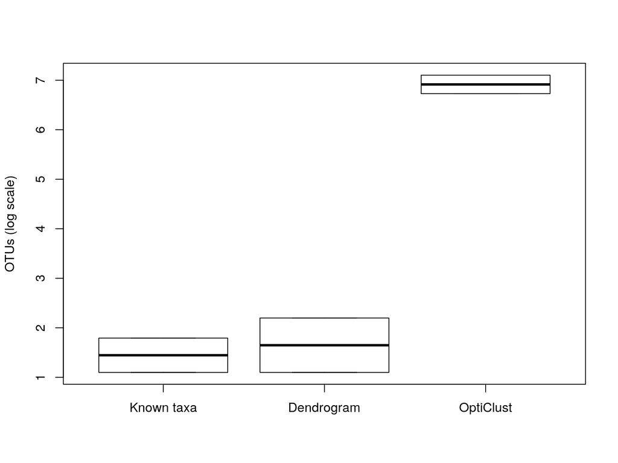

## Discussion

- Marked improvement in number of OTUs identifed over OptiClust
- Greater taxonomic accuracy for simple communities
- Needs to be tested on more complex communities
- OTU clustering approaches based on evolutionary change and dendrograms should be used more